# Hw9

Anusha Ramamurthy

March 27, 2016

Question : Problem Set B

1. What is the experimental unit?
- The experimental unit is the aerobics student
2. From how many populations were the experimental units drawn? Identify the population(s). How many units were drawn from each population? Is this a 1- or a 2-sample problem?
- A single population. Two units are drawn from the same population, one after dynamic stretching another after static stretching(number of watts of energy expanded). This is a 1-sample Problem.
3. How many measurements were taken on each experimental unit? Identify them.
- Two measurements were taken on each experimental unit. D watts of energy exerted during dynamic stretching and S watts of energy exerted during static stretching.
4. Define the parameter(s) of interest for this problem. For 1-sample problems, this should be μ; for 2-sample problems, this should be Delta.
- µ which is the average difference between the watts of energy exerted (D-S)
5. State appropriate null and alternative hypotheses.
- Null hypothesis : level of exertion is lesser in dynamic stretching than in static stretching, so H0 : µ <= 0 and H1 : µ > 0

Question Set C

1. What is the experimental unit?
- Middle aged men
2. From how many populations were the experimental units drawn? Identify the population(s). How many units were drawn from each population? Is this a 1- or a 2-sample problem?
- 2 different set of populations. Type A behavior is characterized by urgency, aggression and ambition; Type B behavior is noncompetitive, more relaxed and less hurried. 2 - sample
3. How many measurements were taken on each experimental unit? Identify them.
- 40 measurements. Cholesterol measurements of 20 heavy men of each behavior type
4. Define the parameter(s) of interest for this problem. For 1-sample problems, this should be μ; for 2-sample problems, this should be Delta.
- The parameters are the cholesterol levels. Delta (µ1 - µ2), where µ1 is the mean cholestrol level of Type A men and µ2 is the mean cholestrol level of Type B men.
5. State appropriate null and alternative hypotheses.
- Type A men have lower or equal cholesterol levels as heavy Type B men, µ1 <= µ2, so H0: Delta <= 0
- Type A men have higher cholesterol levels than heavy Type B men, µ1 > µ2, so H1: Delta > 0
2. Does it seem reasonable to assume that the samples x and y, the observed values of X1, . . . ,Xn1 and Y1, . . . , Yn2 , were drawn from normal distributions? Why or why not?

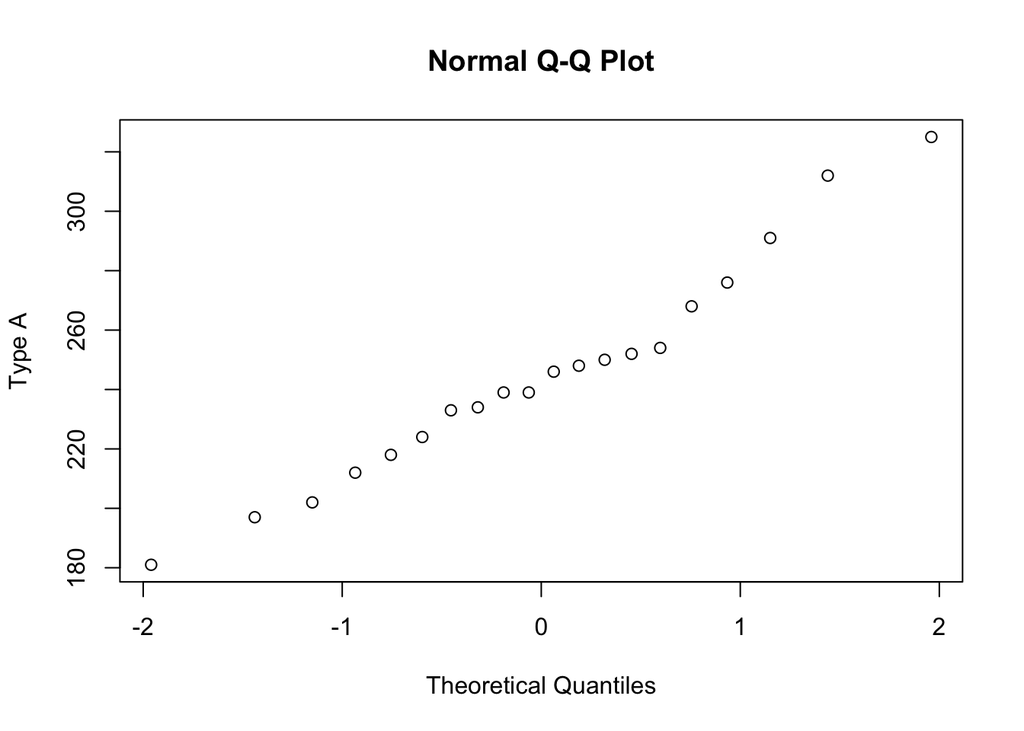

```r
x = c(233 ,291, 312, 250, 246, 197, 268, 224, 239, 239 ,254, 276, 234, 181, 248, 252, 202, 218, 212, 325)
y= c(344, 185, 263, 246, 224, 212, 188, 250, 148, 169,
226, 175, 242, 252 ,153 ,183 ,137, 202, 194, 213)

qqnorm(x,ylab = "Type A")
```

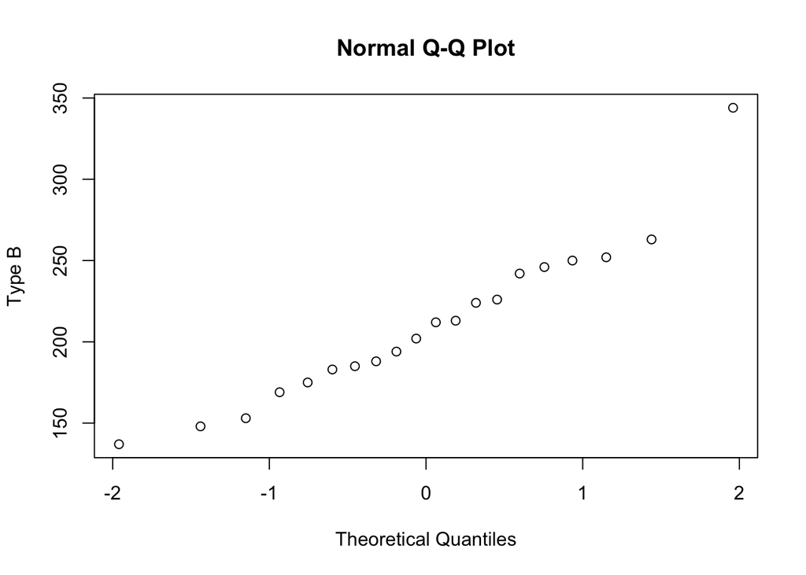

```r
qqnorm(y,ylab = "Type B")
```

- We observe from the probability plot that there is a systematic bend.

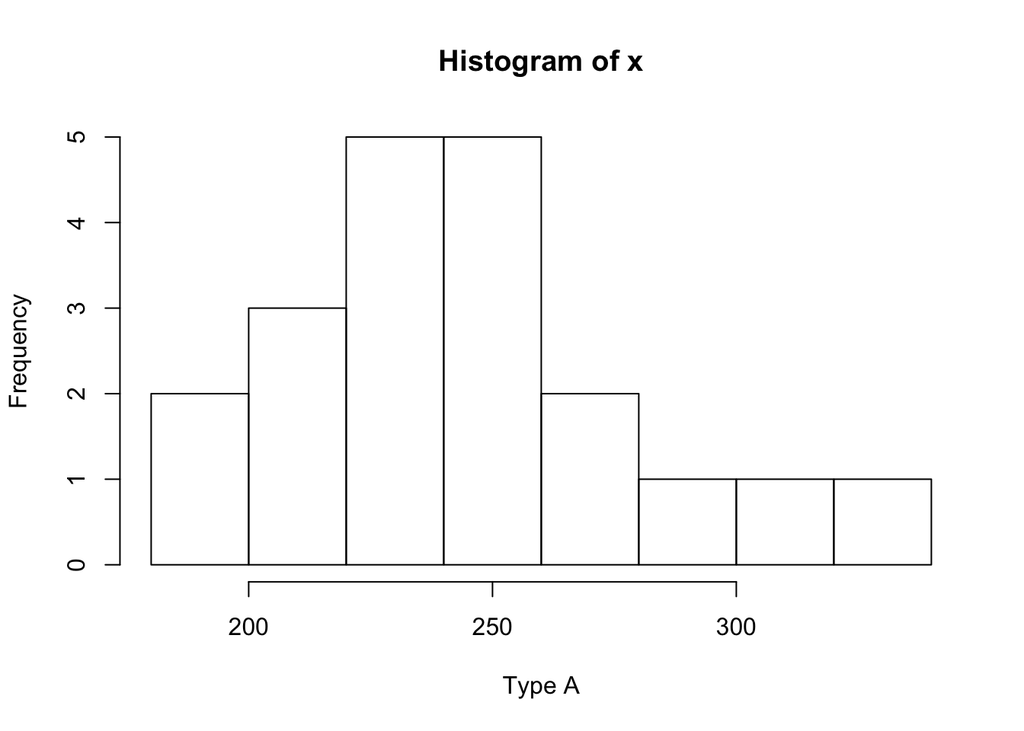

```r
hist(x,xlab = "Type A")
```

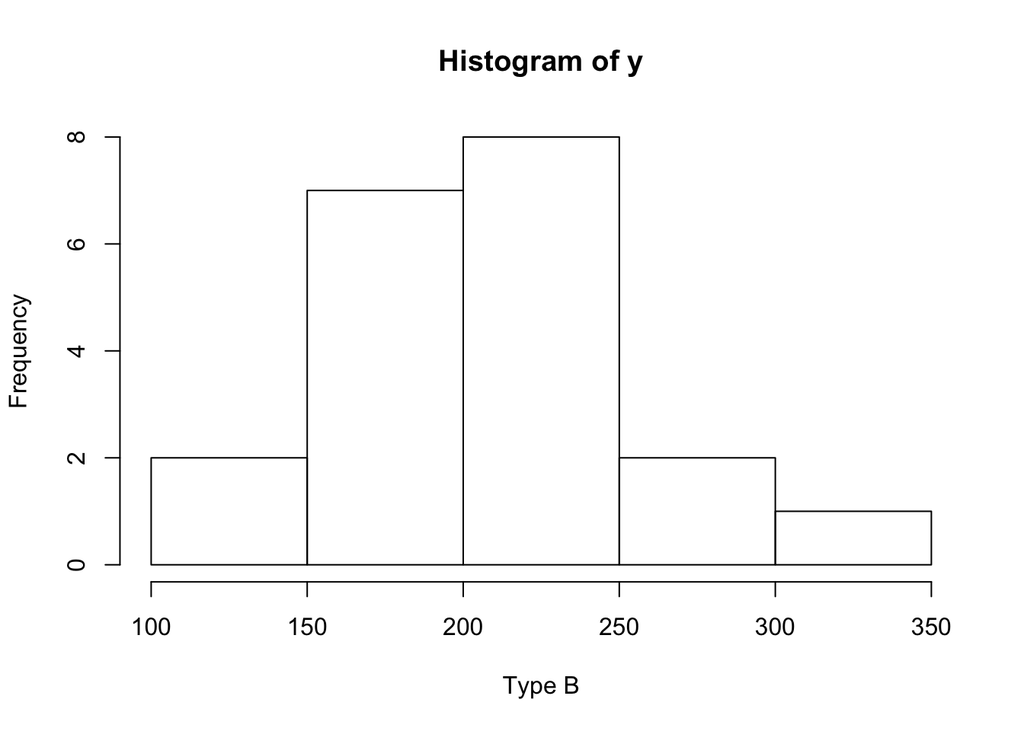

```r
hist(y,xlab = "Type B")
```

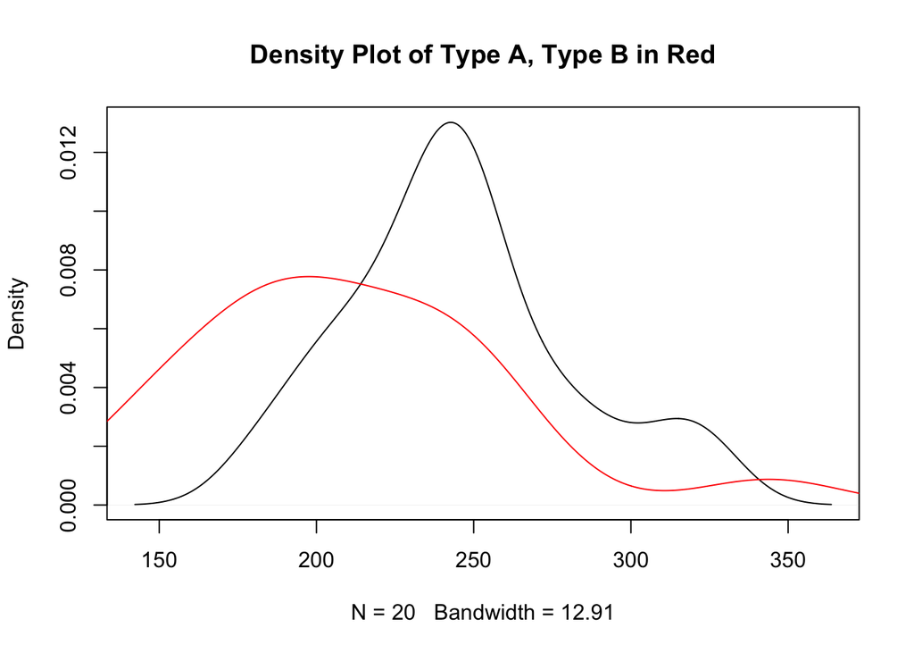

```r
plot(density(x),main = "Density Plot of Type A, Type B in Red")
lines(density(y),col="red")
```

- The density plots show that y does appear more normal than x, if we consider interquatile range to standard deviation , we observe that y is closer to the value of 1.35, however the sample size of 20 is quite small. We cannot conclude if the samples are drawn from normal distributions.

```r
get_iqr = function (s){
q <- as.vector(quantile(s,probs=c(.25,.75)))
iqr <- q[2]-q[1]
return (iqr)
}

#Interquartile range to standard deviation of Type A
get_iqr(x)/sd(x)
```

```
## [1] 0.9552842
```

```r
#Interquartile range to standard deviation of Type B
get_iqr(y)/sd(y)
```

```
## [1] 1.282584
```

3. Assume that the Xi and the Yj are normally distributed.
1. Test the null hypothesis derived above using Welch’s approximate t-test. What is the significance probability? If we adopt a significance level of α = 0.05, should we reject the null hypothesis?

```r
summary(x)
```

```
##    Min. 1st Qu.  Median    Mean 3rd Qu.    Max.
##   181.0   222.5   242.5   245.0   257.5   325.0
```

```r
summary(y)
```

```
##    Min. 1st Qu.  Median    Mean 3rd Qu.    Max.
##   137.0   181.0   207.0   210.3   243.0   344.0
```

```r
delta = (mean(x)-mean(y))
se = sqrt(var(x)/20 + var(y)/20)

t = delta / se
df1 = (var(x)/20+var(y)/20)^2 / ((var(x)/20)^2/19 + (var(y)/20)^2/19)
1 - pt(t, df=df1)
```

```
## [1] 0.007405252
```

```r
q = qt(0.95, df=df1)
lower =  delta- q*se
upper = delta  + q*se
lower
```

```
## [1] 11.84155
```

```r
upper
```

```
## [1] 57.65845
```

Question : Problem Set D

1. Researchers measured urinary β-thromboglobulin excretion in 12 diabetic patients and 12 normal control subjects, reporting their findings in Thrombosis and Haemostasis. The following measurements are Data Set 313 in A Handbook of Small Data Sets:

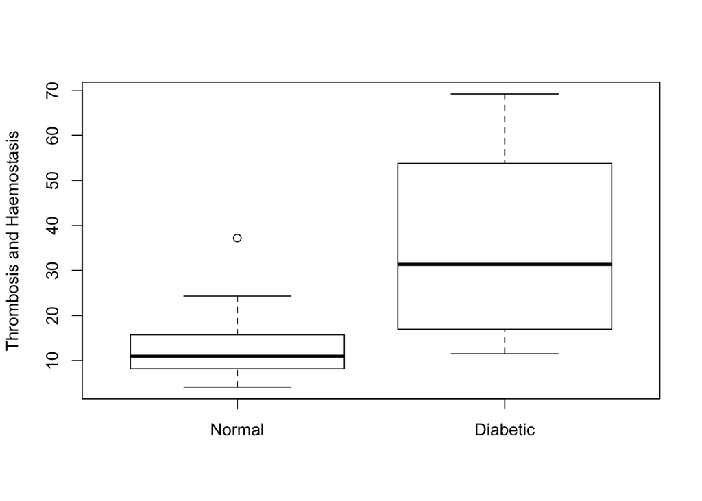

```r
normal = c (4.1 ,6.3 ,7.8 ,8.5 ,8.9, 10.4,
11.5, 12.0 ,13.8 ,17.6, 24.3, 37.2)
diabetic = c(11.5 ,12.1 ,16.1, 17.8, 24.0, 28.8
,33.9 ,40.7 ,51.3, 56.2, 61.7, 69.2)

boxplot(normal,diabetic,names = c("Normal","Diabetic"),ylab = "Thrombosis and Haemostasis")
```

1. Do these measurements appear to be samples from symmetric distributions? Why or why not?

```r
summary(normal)
```

```
##    Min. 1st Qu.  Median    Mean 3rd Qu.    Max.
##   4.100   8.325  10.950  13.530  14.750  37.200
```

```r
summary(diabetic)
```

```
##    Min. 1st Qu.  Median    Mean 3rd Qu.    Max.
##   11.50   17.38   31.35   35.28   52.52   69.20
```

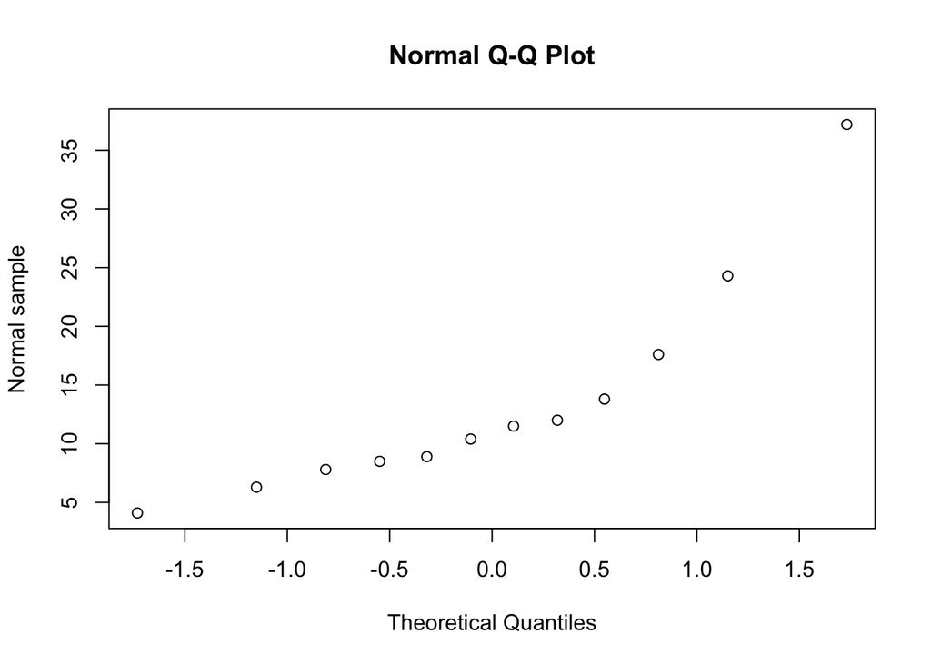

```r
qqnorm(normal, ylab = "Normal sample")
```

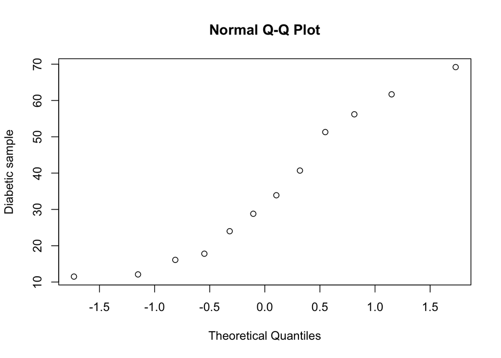

```r
qqnorm(diabetic, ylab = "Diabetic sample")
```

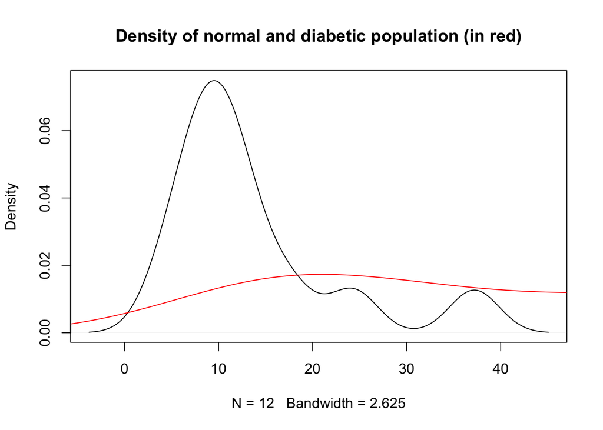

```r
plot(density(normal), main = "Density of normal and diabetic population (in red)")
lines(density(diabetic), col="red")
```

- Since the samples are small we cannot conclude that the distributions are symmetric. There is a systematic bend in the probability plots and the density plot for normal sample shows multiple hills.
2. Both samples of positive real numbers appear to be drawn from distributions that are skewed to the right, i.e., the upper tail of the distribution is longer than the lower tail of the distribution. Often, such distributions can be symmetrized by applying a suitable data transformation.

Investigate the effect of each of these transformations on the above measurements. Do the transformed measurements appear to be samples from symmetric distributions? Which transformation do you prefer?

Two popular candidates are:

The natural logarithm: ui = log(xi) and vj = log(yj).

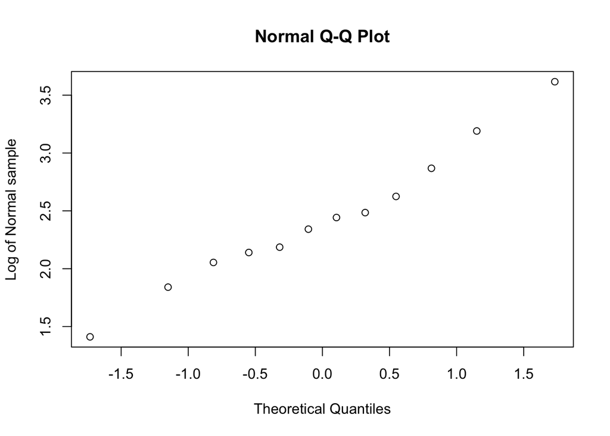

```r
qqnorm(log(normal),ylab = "Log of Normal sample")
```

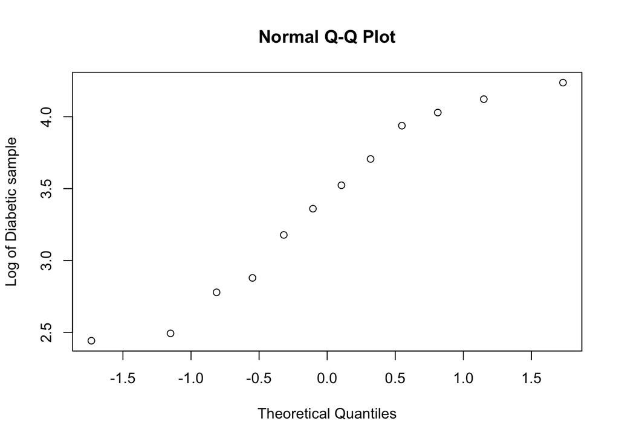

```r
qqnorm(log(diabetic),ylab = "Log of Diabetic sample")
```

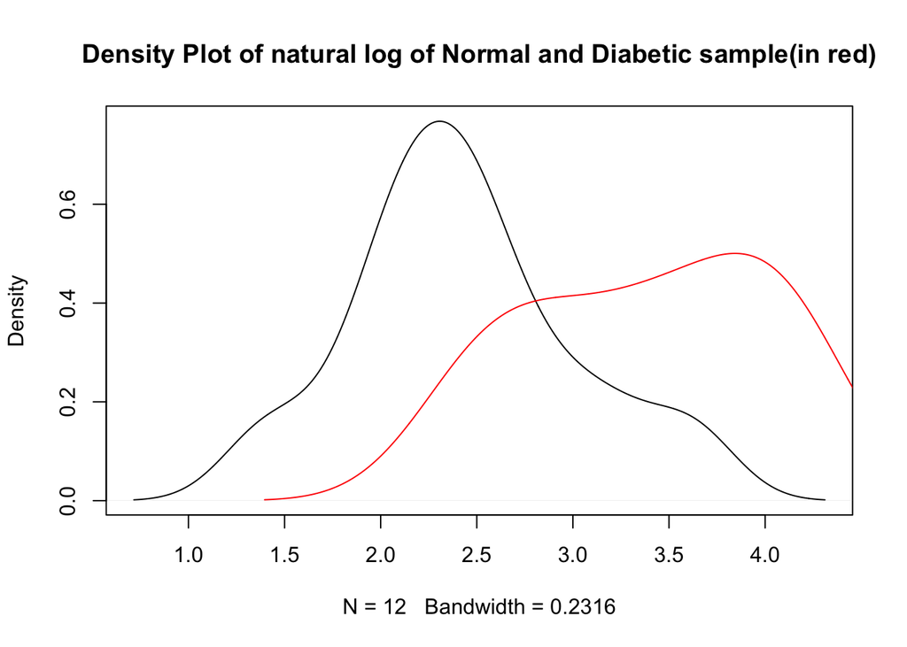

```r
plot(density(log(normal)), main = "Density Plot of natural log of Normal and Diabetic sample(in red)")
lines(density(log(diabetic)), col="red")
```

- The log transformation does appear to push the values higher on the probability plot. However they still have a bend. The density plots do look slightly more symetric.

The square root: ui = √xi and vj = √yj .

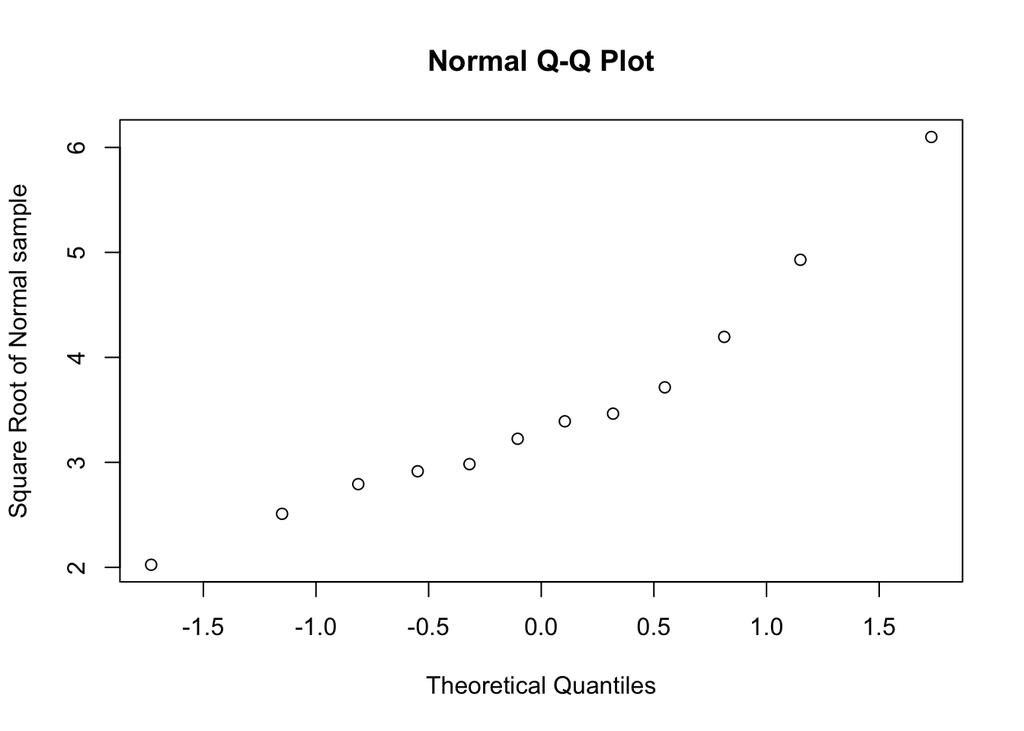

```r
qqnorm(sqrt(normal),ylab = "Square Root of Normal sample")
```

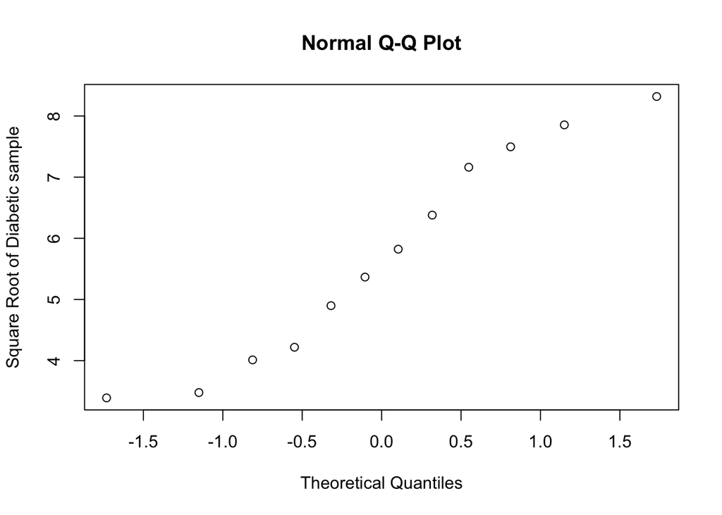

```r
qqnorm(sqrt(diabetic),ylab = "Square Root of Diabetic sample")
```

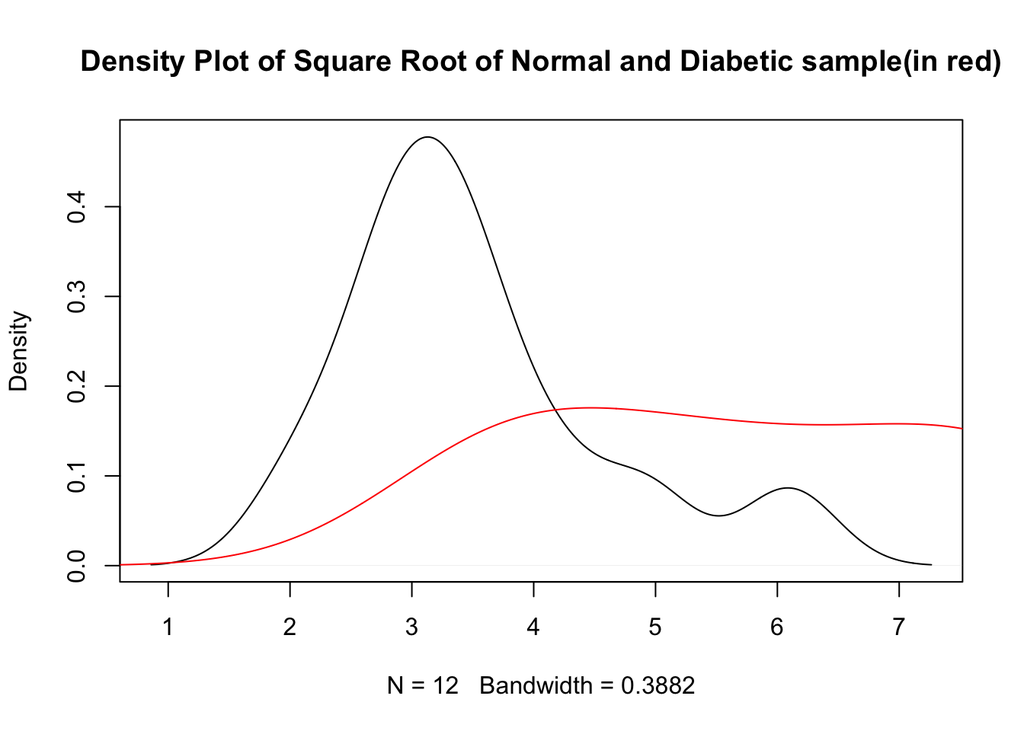

```r
plot(density(sqrt(normal)),main = "Density Plot of Square Root of Normal and Diabetic sample(in red)")
lines(density(sqrt(diabetic)), col="red")
```

- The bends are less pronounced with the sqrt transformation compared to the original samples.However the sqrt transformation does make the samples appear more symmetric. I prefer the natural log transformation.
3. Do the transformed measurements appear to be samples from normal distributions? Why or why not?
- Looking at the probability plots , they do appear more normal than the initial samples. However the sample size is too small to draw the conclusion that these samples are drawn from a normal distribution.
4. The researchers claimed that diabetic patients have increased urinary β-thromboglobulin excretion. Assuming that the transformed measurements are samples from normal distributions, how convincing do you find the evidence for their claim?

```r
wilcox.test(diabetic,normal,conf.int = TRUE)
```

```
##
##  Wilcoxon rank sum test with continuity correction
##
## data:  diabetic and normal
## W = 125.5, p-value = 0.002209
## alternative hypothesis: true location shift is not equal to 0
## 95 percent confidence interval:
##   5.700068 39.299911
## sample estimates:
## difference in location
##               18.92279
```

- The p-value is very small 0.002209. So the null hypothesis can be rejected and we can say that the researchers claim is strong and that diabetic patients have increased urinary β-thromboglobulin excretion.

Question : Problem Set E

1. A film buff has formed the vague impression that movies tend to be longer than they used to be. Are they really longer? Or do they just seem longer? To investigate, he randomly samples U.S. feature films made in 1956 and U.S. feature films made in 1996, obtaining the following results:

```r
m_1956 =  c(74, 114 ,114, 87, 92, 55, 67,
          118, 79 ,83 ,79 ,92 ,99 ,87)
m_1996 = c(70 ,98 ,90 ,95 , 88 ,108 , 110
        ,96 ,91 ,88 ,120 ,96 ,90 ,90)

summary(m_1956)
```

```
##    Min. 1st Qu.  Median    Mean 3rd Qu.    Max.
##   55.00   79.00   87.00   88.57   97.25  118.00
```

```r
summary(m_1996)
```

```
##    Min. 1st Qu.  Median    Mean 3rd Qu.    Max.
##    70.0    90.0    93.0    95.0    97.5   120.0
```

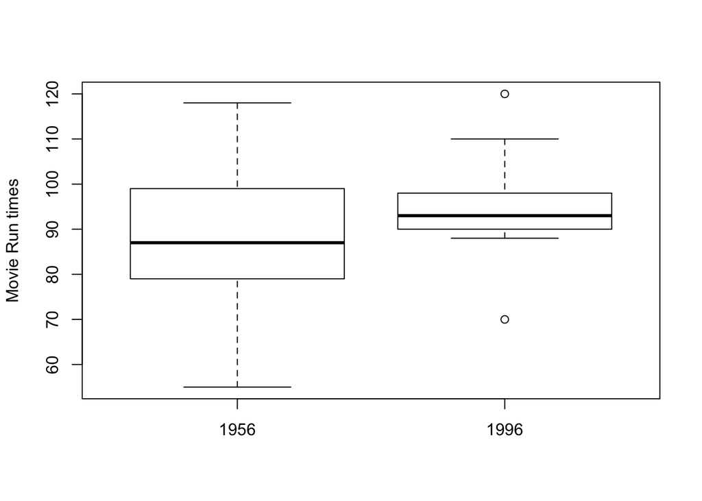

```r
boxplot(m_1956,m_1996,names = c("1956","1996"),ylab = "Movie Run times")
```

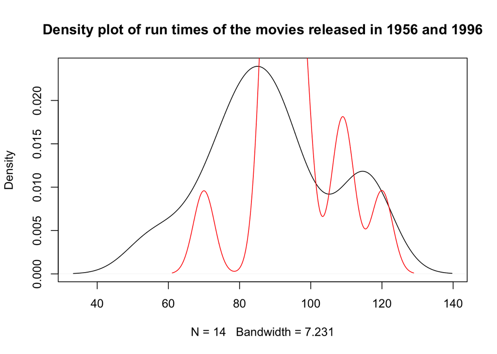

```r
plot(density(m_1956),main = "Density plot of run times of the movies released in 1956 and 1996")
lines(density(m_1996), col="red")
```

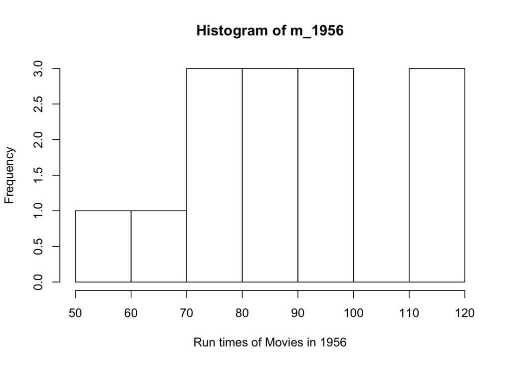

```r
hist(m_1956,xlab = "Run times of Movies in 1956")
```

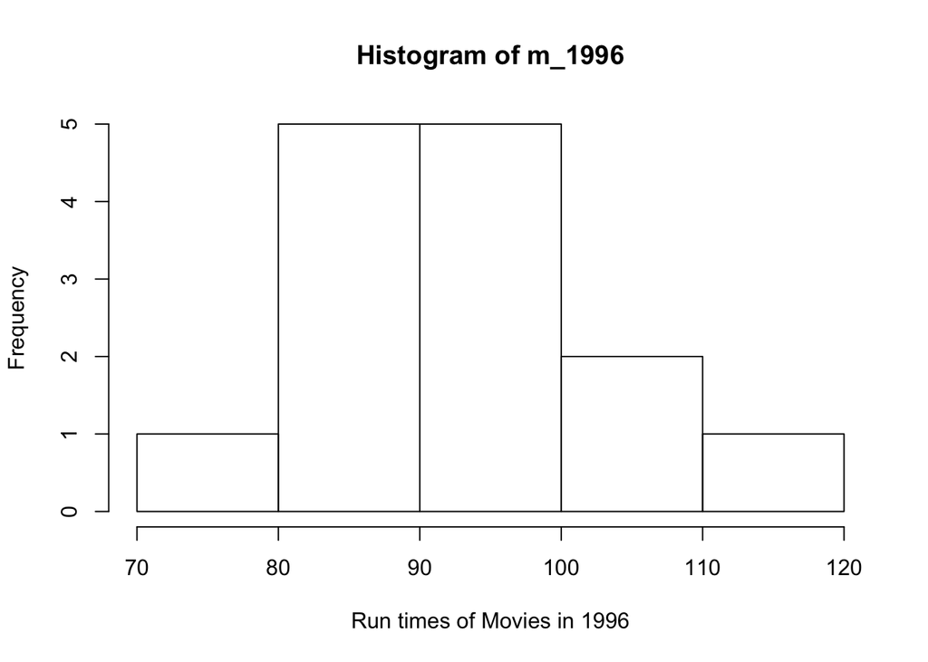

```r
hist(m_1996,xlab = "Run times of Movies in 1996")
```

- The histograms and density plots give no information to conclude if the samples are drawn from a normal population. Lets look at qq plots.

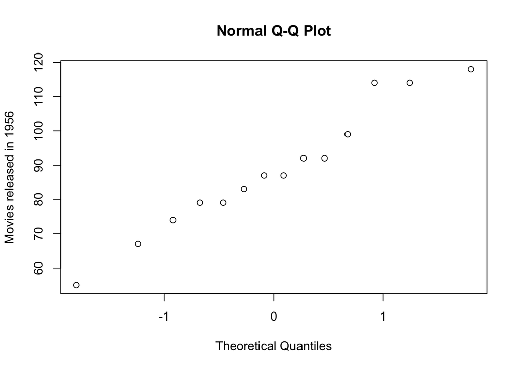

```r
qqnorm(m_1956, ylab = "Movies released in 1956")
```

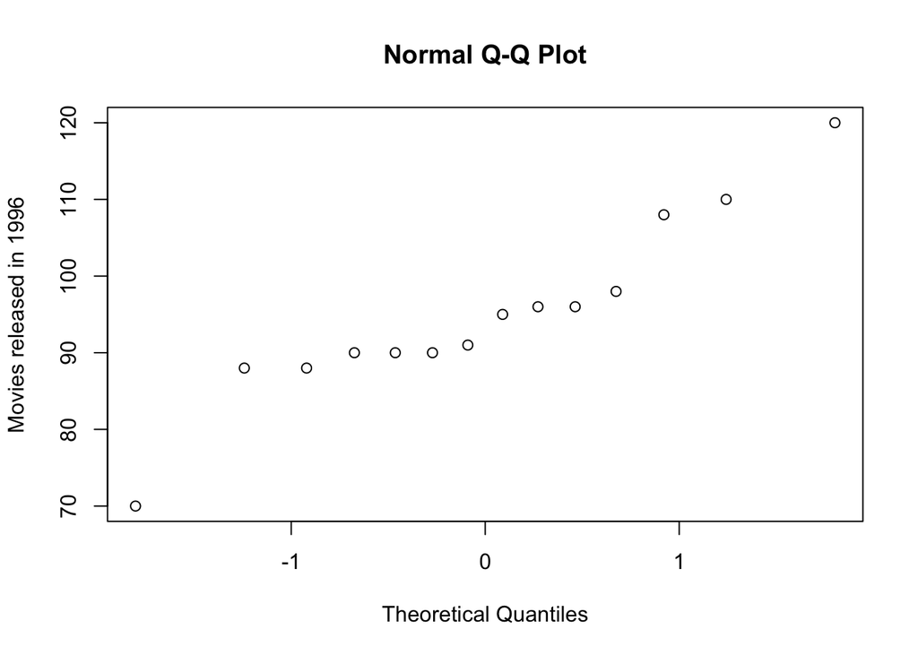

```r
qqnorm(m_1996, ylab = "Movies released in 1996")
```

- The sample from the year 1956 appears almost normal, but there is a slight bend in the values around the 2nd quartile.

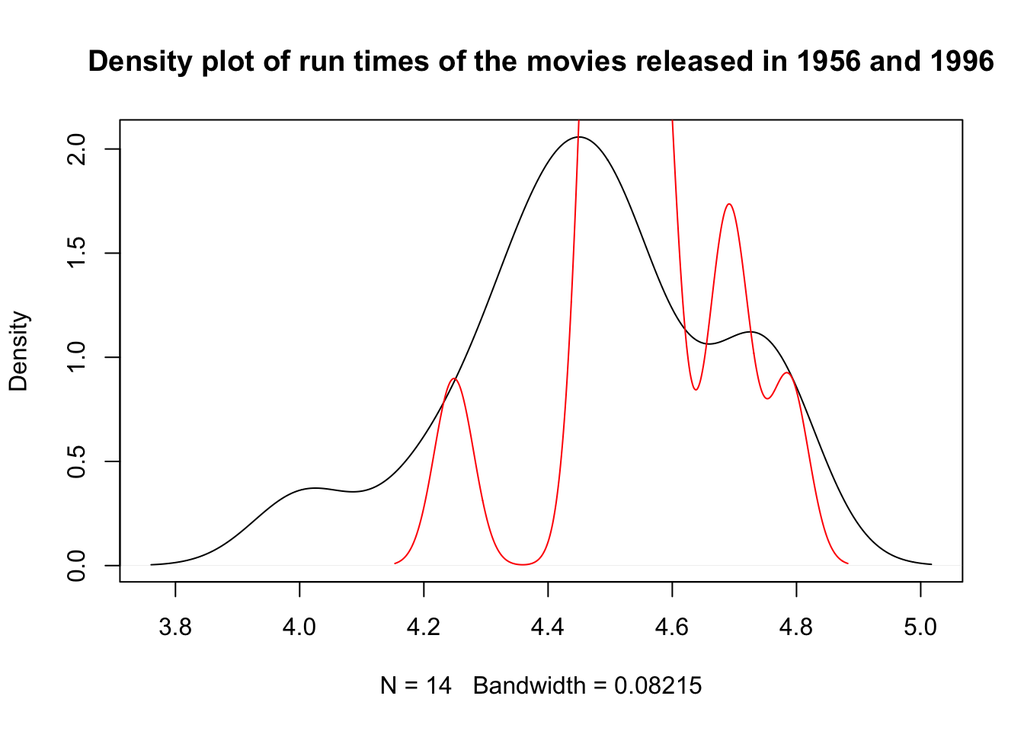

```r
plot(density(log(m_1956)),main = "Density plot of run times of the movies released in 1956 and 1996")
lines(density(log(m_1996)), col="red")
```

- If we transform the samples to a log scale we still see many peaks and no symmetry.

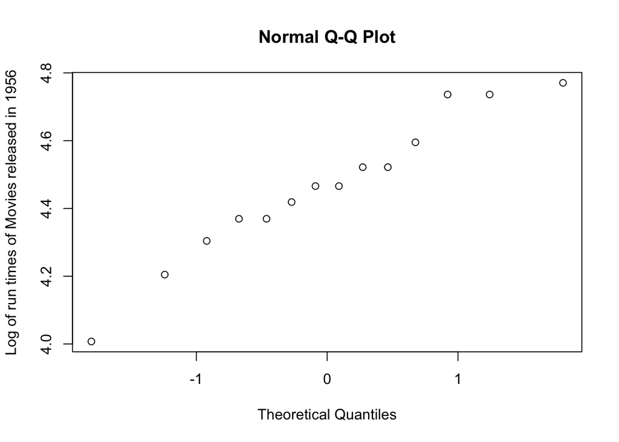

```r
qqnorm(log(m_1956),ylab = "Log of run times of Movies released in 1956")
```

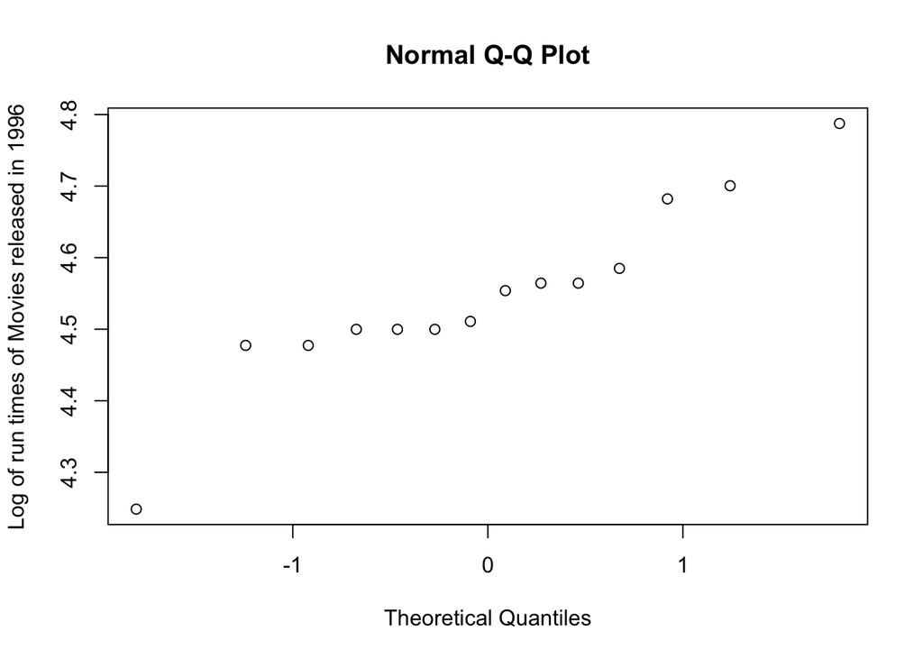

```r
qqnorm(log(m_1996),ylab = "Log of run times of Movies released in 1996")
```

- The qq-plot of 1956 data as before looks more like a straight line. The qq-plot of the 1996 data doesnt look any better than before. Since the sample size is small, we cannot conclude that it is drawn from a normal distribution. We can check welsch’s test, but it will not be correct to conclude based on it since it assumes that it is drawn from a normal population.

```r
t.test(m_1956,m_1996)
```

```
##
##  Welch Two Sample t-test
##
## data:  m_1956 and m_1996
## t = -1.105, df = 22.395, p-value = 0.2809
## alternative hypothesis: true difference in means is not equal to 0
## 95 percent confidence interval:
##  -18.480963   5.623821
## sample estimates:
## mean of x mean of y
##  88.57143  95.00000
```

- Wilcox’s test will be a much better indicator, since it makes no assumptions about the normalitity.

```r
wilcox.test(m_1996,m_1956,conf.int = TRUE)
```

```
##
##  Wilcoxon rank sum test with continuity correction
##
## data:  m_1996 and m_1956
## W = 126, p-value = 0.2058
## alternative hypothesis: true location shift is not equal to 0
## 95 percent confidence interval:
##  -4.000047 17.999975
## sample estimates:
## difference in location
##               7.000011
```

2. Do these data provide convincing evidence that 1996 movies are longer than 1956 movies? Compute a significance probability that may be used to encourage or discourage the film buff’s impression. Explain how this number should be interpreted. Identify and defend any assumptions that you made in your calculations.
- Both the test’s give a p-value of around 0.2. However the sample size is quite small to say with confidence that movies is 1996 are much longer than 1956 sice the confidence intervals show a variation between 4 to 18 mins